# Bölmə 19: Problem Diaqnoz Funksiyası

Kompüter Adaptiv Testləşmə (CAT) Tədrisi - Sistem Diaqnostikası

CAT Tədrisi

2025-07-12

# 1 Giriş

CAT sistemlərinin səmərəli işləməsi üçün problemli sahələrin vaxtında aşkar edilməsi və düzəldilməsi kritik əhəmiyyət daşıyır. Bu bölmədə hərtərəfli problem diaqnoz funksiyasını təqdim edəcəyik ki, bu sistem performansını qiymətləndirməyə və təkmilləşdirmə sahələrini müəyyən etməyə kömək edir.

## 1.1 Problem Diaqnozunun Məqsədləri

1. **Performance Issues Detection**: Performans problemlərinin aşkarlanması
2. **Efficiency Assessment**: Sistemin səmərəliliyinin qiymətləndirməsi
3. **Quality Control**: Keyfiyyət nəzarəti və standartlara uyğunluğun yoxlanılması
4. **Optimization Opportunities**: Optimallaşdırma imkanlarının müəyyən edilməsi
5. **Preventive Maintenance**: Profilaktik təmir və təkmilləşdirmə tövsiyələri

## 1.2 Diaqnostik Yanaşmanın Komponentləri

- **Statistical Indicators**: Statistik göstəricilər
- **Performance Thresholds**: Performans threshold-ları
- **Systematic Patterns**: Sistematik pattern-lər
- **Efficiency Metrics**: Effektivlik ölçüləri
- **Quality Assurance**: Keyfiyyət təminatı

# 2 Test Məlumatlarının Hazırlanması

```r
# Nümunə test məlumatları yaratmaq (realistik problemlərlə)
set.seed(54321)
n_examinees <- 600

# Həqiqi qabiliyyət səviyyələri
true_theta <- rnorm(n_examinees, mean = 0, sd = 1.1)

# Qiymətləndirmə xətası (bəzi problemli test alıcılarla)
base_error <- 0.25
problem_examinees <- sample(1:n_examinees, n_examinees * 0.15)  # 15% problemli
estimation_error <- rep(base_error, n_examinees)
estimation_error[problem_examinees] <- runif(length(problem_examinees), 0.4, 0.8)
estimation_error <- abs(rnorm(n_examinees, 0, estimation_error))

# Qiymətləndirilmiş theta
estimated_theta <- true_theta + rnorm(n_examinees, 0, estimation_error)

# Standart xəta (ekstrem qabiliyyətlərdə və problemli hallarda yüksək)
base_se <- 0.22 + 0.08 * abs(true_theta) / 2
noise_se <- rnorm(n_examinees, 0, 0.04)
standard_error <- pmax(0.12, base_se + noise_se)
standard_error[problem_examinees] <- standard_error[problem_examinees] * 1.3

# İdarə edilən item sayı (bəzi hallarda çox yüksək)
base_items <- 18
item_adjustment <- pmax(0, floor(2.5 * abs(true_theta)))
items_administered <- base_items + item_adjustment + sample(-2:4, n_examinees, replace = TRUE)

# Problemli test alıcılar üçün item sayını artır
high_item_examinees <- sample(1:n_examinees, n_examinees * 0.12)  # 12% yüksək item
items_administered[high_item_examinees] <- items_administered[high_item_examinees] + sample(8:15, length(high_item_examinees), replace = TRUE)
items_administered <- pmax(6, pmin(45, items_administered))

# Bias hesablanması (sistematik bias əlavə et)
systematic_bias <- 0.08  # Sistemdə kiçik bias
bias <- (estimated_theta - true_theta) + systematic_bias

# Effektivlik göstəricisi
efficiency <- 1 / (standard_error * sqrt(items_administered))

# Precision indicator
precision_threshold <- 0.30
precision_met <- standard_error <= precision_threshold

# Məlumat çərçivəsinin yaradılması
results_summary <- data.frame(
    examinee_id = 1:n_examinees,
    true_theta = true_theta,
    estimated_theta = estimated_theta,
    estimation_error = estimation_error,
    standard_error = standard_error,
    items_administered = items_administered,
    bias = bias,
    efficiency = efficiency,
    precision_met = precision_met
)

# Sadə item bank məlumatı (simulyasiya üçün)
item_bank <- data.frame(
    item_id = 1:500,
    difficulty = rnorm(500, 0, 1),
    discrimination = rlnorm(500, 0.2, 0.3),
    guessing = runif(500, 0, 0.25)
)

cat("=== TEST MƏLUMATLARI HAZIRLANDI ===\n")
```

```
## === TEST MƏLUMATLARI HAZIRLANDI ===
```

```r
cat("Test alıcı sayı:", nrow(results_summary), "\n")
```

```
## Test alıcı sayı: 600
```

```r
cat("Item bank ölçüsü:", nrow(item_bank), "item\n")
```

```
## Item bank ölçüsü: 500 item
```

```r
cat("Orta test uzunluğu:", round(mean(items_administered), 1), "item\n")
```

```
## Orta test uzunluğu: 22.1 item
```

```r
cat("Orta qiymətləndirmə xətası:", round(mean(estimation_error), 3), "\n\n")
```

```
## Orta qiymətləndirmə xətası: 0.249
```

# 3 Əsas Problem Diaqnoz Funksiyası

```r
# Problem diagnoz funksiyası (sizin kodunuza əsasən genişləndirilmiş)
diagnose_problems <- function(results_df, item_bank = NULL) {
    cat("=== PROBLEMLİ SAHƏLƏRİN ANALİZİ ===\n\n")

    diagnosis_results <- list()

    # 1. Aşağı dəqiqlik olan test alıcıları
    low_accuracy_threshold <- 0.5
    low_accuracy <- results_df[results_df$estimation_error > low_accuracy_threshold, ]

    cat("📊 DƏQİQLİK PROBLEMLƏRİ:\n")
    if (nrow(low_accuracy) > 0) {
        percentage <- round((nrow(low_accuracy) / nrow(results_df)) * 100, 1)
        cat("⚠️ Aşağı dəqiqlik olan test alıcıları:", nrow(low_accuracy),
            "(", percentage, "%)\n")
        cat("   Orta xəta:", round(mean(low_accuracy$estimation_error), 3), "\n")
        cat("   Tövsiyə: Bu şəxslər üçün minimum tapşırıq sayı artırılmalıdır.\n")
        diagnosis_results$low_accuracy <- low_accuracy
    } else {
        cat("✅ Dəqiqlik problemləri aşkar edilmədi.\n")
    }
    cat("\n")

    # 2. Çox tapşırıq istifadə edən test alıcıları
    high_items_threshold <- 25
    high_items <- results_df[results_df$items_administered > high_items_threshold, ]

    cat("📈 TEST UZUNLUĞU PROBLEMLƏRİ:\n")
    if (nrow(high_items) > 0) {
        percentage <- round((nrow(high_items) / nrow(results_df)) * 100, 1)
        cat("⚠️ Çox tapşırıq istifadə edən test alıcıları:", nrow(high_items),
            "(", percentage, "%)\n")
        cat("   Orta item sayı:", round(mean(high_items$items_administered), 1), "\n")
        cat("   Tövsiyə: SE threshold yenidən nəzərdən keçirilməlidir.\n")
        diagnosis_results$high_items <- high_items
    } else {
        cat("✅ Test uzunluğu problemləri aşkar edilmədi.\n")
    }
    cat("\n")

    # 3. Sistematik bias
    bias_threshold <- 0.1
    mean_bias <- mean(results_df$bias)

    cat("⚖️ BİAS ANALİZİ:\n")
    if (abs(mean_bias) > bias_threshold) {
        cat("⚠️ Sistematik bias aşkar edildi:", round(mean_bias, 3), "\n")
        cat("   Bias standart sapması:", round(sd(results_df$bias), 3), "\n")
        cat("   Tövsiyə: Tapşırıq bankı və ya qiymətləndirmə metodu yoxlanmalıdır.\n")
        diagnosis_results$systematic_bias <- mean_bias
    } else {
        cat("✅ Sistematik bias problemi aşkar edilmədi.\n")
    }
    cat("\n")

    # 4. Aşağı korrelyasiya
    correlation_threshold <- 0.85
    correlation <- cor(results_df$true_theta, results_df$estimated_theta)

    cat("🔗 VALİDLİK ANALİZİ:\n")
    if (correlation < correlation_threshold) {
        cat("⚠️ Aşağı validlik korrelyasiyası:", round(correlation, 3), "\n")
        cat("   Tövsiyə: Tapşırıq keyfiyyəti və bank strukturu yoxlanmalıdır.\n")
        diagnosis_results$low_correlation <- correlation
    } else {
        cat("✅ Validlik korrelyasiyası qənaətbəxşdir:", round(correlation, 3), "\n")
    }
    cat("\n")

    # 5. Precision problemləri
    precision_rate <- mean(results_df$precision_met) * 100

    cat("🎯 PRECİSİON ANALİZİ:\n")
    if (precision_rate < 75) {
        cat("⚠️ Aşağı precision achievement:", round(precision_rate, 1), "%\n")
        cat("   Tövsiyə: SE threshold və ya test strategiyası yenidən qurulmalıdır.\n")
        diagnosis_results$low_precision <- precision_rate
    } else {
        cat("✅ Precision achievement qənaətbəxşdir:", round(precision_rate, 1), "%\n")
    }
    cat("\n")

    return(diagnosis_results)
}

# Problem diaqnozunu çalışdırın
diagnosis_results <- diagnose_problems(results_summary, item_bank)
```

```
## === PROBLEMLİ SAHƏLƏRİN ANALİZİ ===
##
## 📊 DƏQİQLİK PROBLEMLƏRİ:
## ⚠️ Aşağı dəqiqlik olan test alıcıları: 59 ( 9.8 %)
##    Orta xəta: 0.788
##    Tövsiyə: Bu şəxslər üçün minimum tapşırıq sayı artırılmalıdır.
##
## 📈 TEST UZUNLUĞU PROBLEMLƏRİ:
## ⚠️ Çox tapşırıq istifadə edən test alıcıları: 89 ( 14.8 %)
##    Orta item sayı: 31.5
##    Tövsiyə: SE threshold yenidən nəzərdən keçirilməlidir.
##
## ⚖️ BİAS ANALİZİ:
## ✅ Sistematik bias problemi aşkar edilmədi.
##
## 🔗 VALİDLİK ANALİZİ:
## ✅ Validlik korrelyasiyası qənaətbəxşdir: 0.949
##
## 🎯 PRECİSİON ANALİZİ:
## ⚠️ Aşağı precision achievement: 73.5 %
##    Tövsiyə: SE threshold və ya test strategiyası yenidən qurulmalıdır.
```

# 4 Ətraflı Problem Analizi

```r
# Ətraflı problem analizi
perform_detailed_diagnosis <- function(results_df, diagnosis_results) {

    cat("=== ƏTRAFLІ PROBLEMLİ SAHƏLƏR ANALİZİ ===\n\n")

    detailed_analysis <- list()

    # 1. Performans metrikləri üzrə bölgü
    cat("📊 PERFORMANS METRİKLƏRİ BÖLGÜSÜ:\n")

    # Error bölgüsü
    error_categories <- cut(results_df$estimation_error,
                          breaks = c(0, 0.3, 0.5, 0.7, Inf),
                          labels = c("Əla (≤0.3)", "Yaxşı (0.3-0.5)",
                                   "Orta (0.5-0.7)", "Zəif (>0.7)"))
    error_distribution <- table(error_categories)

    cat("Qiymətləndirmə xətası bölgüsü:\n")
    for (i in 1:length(error_distribution)) {
        percentage <- round((error_distribution[i] / sum(error_distribution)) * 100, 1)
        cat("  ", names(error_distribution)[i], ":", error_distribution[i],
            "(", percentage, "%)\n")
    }
    cat("\n")

    # Item sayı bölgüsü
    item_categories <- cut(results_df$items_administered,
                          breaks = c(0, 15, 20, 25, Inf),
                          labels = c("Qısa (≤15)", "Orta (16-20)",
                                   "Uzun (21-25)", "Çox uzun (>25)"))
    item_distribution <- table(item_categories)

    cat("Test uzunluğu bölgüsü:\n")
    for (i in 1:length(item_distribution)) {
        percentage <- round((item_distribution[i] / sum(item_distribution)) * 100, 1)
        cat("  ", names(item_distribution)[i], ":", item_distribution[i],
            "(", percentage, "%)\n")
    }
    cat("\n")

    # 2. Qabiliyyət səviyyələrinə görə problemlər
    cat("🎚️ QABİLİYYƏT SƏVİYYƏLƏRİNƏ GÖRƏ PROBLEM ANALİZİ:\n")

    results_df$ability_level <- cut(results_df$true_theta,
                                   breaks = c(-Inf, -1, 0, 1, Inf),
                                   labels = c("Aşağı", "Orta-Aşağı", "Orta-Yüksək", "Yüksək"))

    ability_problems <- results_df %>%
        group_by(ability_level) %>%
        summarise(
            count = n(),
            high_error_rate = round(mean(estimation_error > 0.5) * 100, 1),
            high_items_rate = round(mean(items_administered > 25) * 100, 1),
            low_precision_rate = round(mean(!precision_met) * 100, 1),
            mean_efficiency = round(mean(efficiency), 4),
            .groups = 'drop'
        )

    print(ability_problems)
    cat("\n")

    # 3. Ekstrem halların analizi
    cat("🔍 EKSTREM HALLAR ANALİZİ:\n")

    # En problemli test alıcılar
    worst_performers <- results_df %>%
        arrange(desc(estimation_error)) %>%
        head(10) %>%
        select(examinee_id, true_theta, estimated_theta, estimation_error,
               items_administered, standard_error)

    cat("Ən problemli 10 test alıcı:\n")
    print(worst_performers)
    cat("\n")

    # Ən səmərəsiz testlər
    inefficient_tests <- results_df %>%
        filter(items_administered > 30 & estimation_error > 0.4) %>%
        arrange(desc(items_administered)) %>%
        select(examinee_id, true_theta, estimation_error, items_administered, efficiency)

    if (nrow(inefficient_tests) > 0) {
        cat("Səmərəsiz testlər (>30 item və >0.4 xəta):\n")
        print(head(inefficient_tests, 10))
    } else {
        cat("✅ Əhəmiyyətli səmərəsiz test aşkar edilmədi.\n")
    }
    cat("\n")

    detailed_analysis$error_distribution <- error_distribution
    detailed_analysis$item_distribution <- item_distribution
    detailed_analysis$ability_problems <- ability_problems
    detailed_analysis$worst_performers <- worst_performers
    detailed_analysis$inefficient_tests <- inefficient_tests

    return(detailed_analysis)
}

# Ətraflı analizi həyata keçir
detailed_diagnosis <- perform_detailed_diagnosis(results_summary, diagnosis_results)
```

```
## === ƏTRAFLІ PROBLEMLİ SAHƏLƏR ANALİZİ ===
##
## 📊 PERFORMANS METRİKLƏRİ BÖLGÜSÜ:
## Qiymətləndirmə xətası bölgüsü:
##    Əla (≤0.3) : 423 ( 70.5 %)
##    Yaxşı (0.3-0.5) : 118 ( 19.7 %)
##    Orta (0.5-0.7) : 33 ( 5.5 %)
##    Zəif (>0.7) : 26 ( 4.3 %)
##
## Test uzunluğu bölgüsü:
##    Qısa (≤15) : 0 ( 0 %)
##    Orta (16-20) : 266 ( 44.3 %)
##    Uzun (21-25) : 245 ( 40.8 %)
##    Çox uzun (>25) : 89 ( 14.8 %)
##
## 🎚️ QABİLİYYƏT SƏVİYYƏLƏRİNƏ GÖRƏ PROBLEM ANALİZİ:
## # A tibble: 4 × 6
##   ability_level count high_error_rate high_items_rate low_precision_rate
##   <fct>         <int>           <dbl>           <dbl>              <dbl>
## 1 Aşağı           111             4.5            18.9               47.7
## 2 Orta-Aşağı      203            10.8            11.8               13.3
## 3 Orta-Yüksək     176            12.5            11.4               13.6
## 4 Yüksək          110             9.1            21.8               50
## # ℹ 1 more variable: mean_efficiency <dbl>
##
## 🔍 EKSTREM HALLAR ANALİZİ:
## Ən problemli 10 test alıcı:
##    examinee_id true_theta estimated_theta estimation_error items_administered
## 1          447 -0.2503777      -4.3378355         2.091088                 16
## 2          282  1.9309072       4.2027063         1.710493                 20
## 3          249 -0.4685602      -0.9463684         1.672148                 19
## 4          453  0.3454425      -0.1110744         1.562482                 19
## 5          335  0.9196792       1.1815099         1.425856                 23
## 6          579 -0.7501180       1.0757645         1.282564                 17
## 7          199  1.8053527       1.0553777         1.156731                 21
## 8           13  1.6249731       1.9969979         1.151521                 21
## 9            3 -0.8624371       0.7794199         1.108288                 19
## 10          72  2.2956419       0.6774680         1.073857                 23
##    standard_error
## 1       0.4258405
## 2       0.4061737
## 3       0.2814342
## 4       0.2864310
## 5       0.2594309
## 6       0.2877764
## 7       0.3961811
## 8       0.3617493
## 9       0.2974532
## 10      0.4361305
##
## Səmərəsiz testlər (>30 item və >0.4 xəta):
##   examinee_id   true_theta estimation_error items_administered efficiency
## 1          33 -2.273881030        0.5180356                 35  0.4293733
## 2         164 -0.107733021        1.0429853                 34  0.7509667
## 3         417  0.003322406        0.4480343                 31  0.7853958
## 4         553 -0.151086328        0.4937564                 31  0.6658143
```

# 5 Problem Vizualizasiyaları

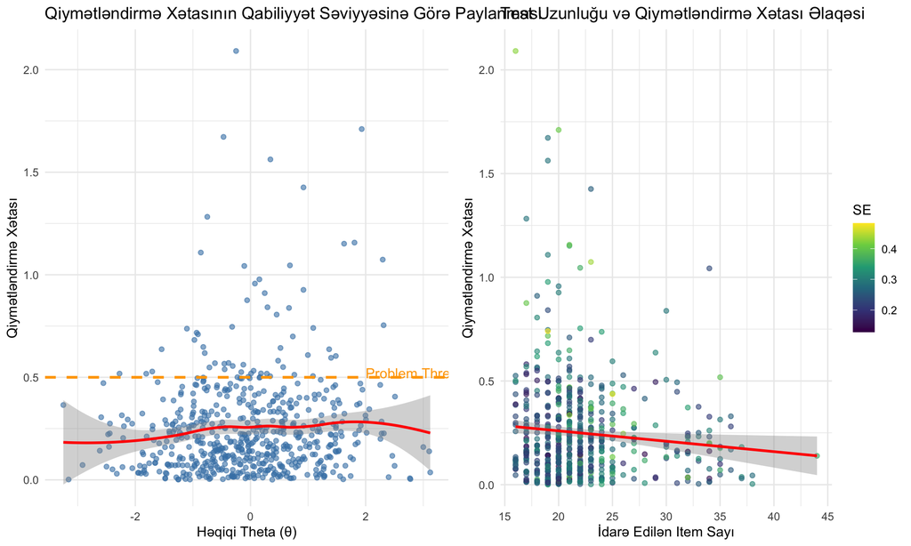

```r
# Problem sahələrinin vizualizasiyası
create_diagnostic_plots <- function(results_df, diagnosis_results) {

    # 1. Error distribution by theta level
    p1 <- ggplot(results_df, aes(x = true_theta, y = estimation_error)) +
        geom_point(alpha = 0.6, color = "steelblue") +
        geom_smooth(method = "loess", color = "red", se = TRUE) +
        geom_hline(yintercept = 0.5, color = "orange", linetype = "dashed", size = 1) +
        labs(title = "Qiymətləndirmə Xətasının Qabiliyyət Səviyyəsinə Görə Paylanması",
             x = "Həqiqi Theta (θ)", y = "Qiymətləndirmə Xətası") +
        theme_minimal() +
        annotate("text", x = 2, y = 0.52, label = "Problem Threshold = 0.5",
                color = "orange", hjust = 0)

    # 2. Items vs Error relationship
    p2 <- ggplot(results_df, aes(x = items_administered, y = estimation_error)) +
        geom_point(alpha = 0.6, aes(color = standard_error)) +
        geom_smooth(method = "lm", color = "red", se = TRUE) +
        scale_color_viridis_c(name = "SE") +
        labs(title = "Test Uzunluğu və Qiymətləndirmə Xətası Əlaqəsi",
             x = "İdarə Edilən Item Sayı", y = "Qiymətləndirmə Xətası") +
        theme_minimal()

    # 3. Problem distribution by ability groups
    results_df$ability_group <- cut(results_df$true_theta,
                                   breaks = c(-Inf, -1, 0, 1, Inf),
                                   labels = c("Aşağı", "Orta-Aşağı", "Orta-Yüksək", "Yüksək"))

    problem_summary <- results_df %>%
        group_by(ability_group) %>%
        summarise(
            high_error = sum(estimation_error > 0.5),
            high_items = sum(items_administered > 25),
            low_precision = sum(!precision_met),
            total = n(),
            .groups = 'drop'
        ) %>%
        pivot_longer(cols = c(high_error, high_items, low_precision),
                     names_to = "problem_type", values_to = "count") %>%
        mutate(problem_type = case_when(
            problem_type == "high_error" ~ "Yüksək Xəta",
            problem_type == "high_items" ~ "Çox Item",
            problem_type == "low_precision" ~ "Aşağı Precision"
        ))

    p3 <- ggplot(problem_summary, aes(x = ability_group, y = count, fill = problem_type)) +
        geom_col(position = "dodge", alpha = 0.8) +
        scale_fill_viridis_d() +
        labs(title = "Qabiliyyət Qruplarına Görə Problem Sayları",
             x = "Qabiliyyət Qrupu", y = "Problem Sayı",
             fill = "Problem Növü") +
        theme_minimal()

    # 4. Efficiency distribution
    p4 <- ggplot(results_df, aes(x = ability_group, y = efficiency, fill = ability_group)) +
        geom_boxplot(alpha = 0.7) +
        scale_fill_viridis_d() +
        scale_y_log10() +
        labs(title = "Qabiliyyət Qruplarına Görə Effektivlik Paylanması",
             x = "Qabiliyyət Qrupu", y = "Effektivlik (log scale)") +
        theme_minimal() +
        theme(legend.position = "none")

    return(list(error_theta = p1, items_error = p2, problems_by_group = p3, efficiency = p4))
}

# Diagnostic plotları yaratmaq
diagnostic_plots <- create_diagnostic_plots(results_summary, diagnosis_results)

# Plotları göstər
grid.arrange(diagnostic_plots$error_theta, diagnostic_plots$items_error, ncol = 2)
```

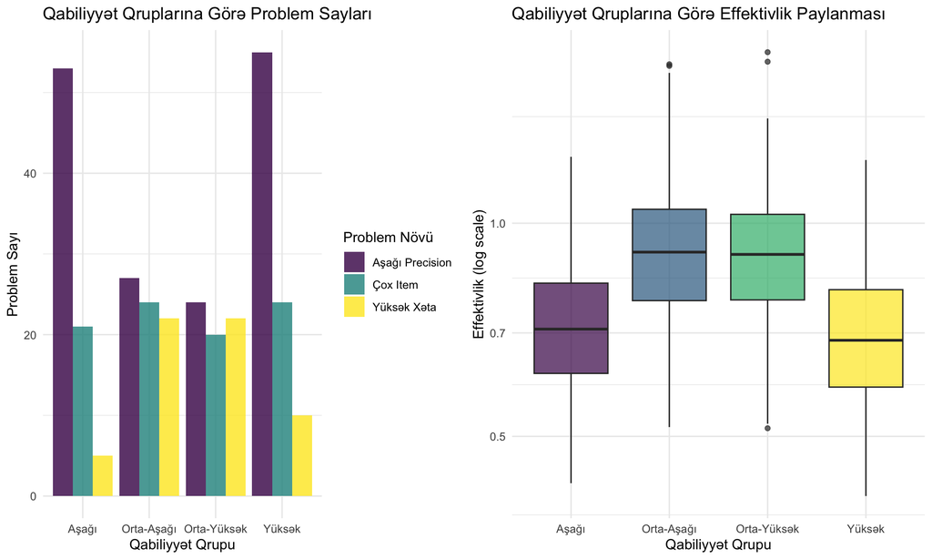

```r
# Əlavə diagnostic plotlar
grid.arrange(diagnostic_plots$problems_by_group, diagnostic_plots$efficiency, ncol = 2)
```

# 6 Tövsiyələr və Həll Yolları

```r
# Tövsiyələr və həll yolları
generate_recommendations <- function(results_df, diagnosis_results, detailed_analysis) {

    cat("=== TÖVSİYƏLƏR VƏ HƏLL YOLLARI ===\n\n")

    recommendations <- list()

    # Problemlərin prioritet sırası
    cat("🔥 PRİORİTET SİRASI:\n")

    priority_issues <- c()

    # Yüksək prioritet problemlər
    if (!is.null(diagnosis_results$low_correlation)) {
        priority_issues <- c(priority_issues, "🔴 YÜKSƏK: Validlik problemi")
    }

    if (!is.null(diagnosis_results$systematic_bias)) {
        priority_issues <- c(priority_issues, "🔴 YÜKSƏK: Sistematik bias")
    }

    low_accuracy_rate <- mean(results_df$estimation_error > 0.5) * 100
    if (low_accuracy_rate > 20) {
        priority_issues <- c(priority_issues, "🔴 YÜKSƏK: Yaygın dəqiqlik problemləri")
    }

    # Orta prioritet problemlər
    if (!is.null(diagnosis_results$low_precision)) {
        priority_issues <- c(priority_issues, "🟡 ORTA: Precision achievement problemi")
    }

    high_items_rate <- mean(results_df$items_administered > 25) * 100
    if (high_items_rate > 15) {
        priority_issues <- c(priority_issues, "🟡 ORTA: Səmərəlilik problemi")
    }

    if (length(priority_issues) == 0) {
        cat("✅ Ciddi problemlər aşkar edilmədi.\n")
    } else {
        for (issue in priority_issues) {
            cat("", issue, "\n")
        }
    }
    cat("\n")

    # Spesifik həll yolları
    cat("💡 SPESİFİK HƏLL YOLLARI:\n\n")

    # 1. Dəqiqlik problemləri üçün
    if (low_accuracy_rate > 10) {
        cat("🎯 DƏQİQLİK TƏKMİLLƏŞDİRMƏSİ:\n")
        cat("  • Minimum test uzunluğunu 15-dən 20-yə artırın\n")
        cat("  • SE threshold-nu 0.30-dan 0.25-ə azaldın\n")
        cat("  • Yüksək informativ itemləri prioritetləşdirin\n")
        cat("  • Ekstrem qabiliyyət səviyyələri üçün xüsusi kriteriyalar tətbiq edin\n\n")
    }

    # 2. Səmərəlilik problemləri üçün
    if (high_items_rate > 10) {
        cat("⚡ SƏMƏRƏLİLİK TƏKMİLLƏŞDİRMƏSİ:\n")
        cat("  • Maximum test uzunluğunu 30-dan 25-ə azaldın\n")
        cat("  • Adaptiv SE threshold strategiyası tətbiq edin\n")
        cat("  • Item selection alqoritmini optimallaşdırın\n")
        cat("  • Multi-stage adaptive testing nəzərdən keçirin\n\n")
    }

    # 3. Bias problemləri üçün
    if (!is.null(diagnosis_results$systematic_bias)) {
        cat("⚖️ BIAS DÜZƏLİŞİ:\n")
        cat("  • Item bank kalibrasyonunu yenidən aparın\n")
        cat("  • DIF (Differential Item Functioning) analizi həyata keçirin\n")
        cat("  • Ability estimation metodunu yoxlayın\n")
        cat("  • Linking və equating prosedurlarını nəzərdən keçirin\n\n")
    }

    # 4. Validlik problemləri üçün
    if (!is.null(diagnosis_results$low_correlation)) {
        cat("🔗 VALİDLİK TƏKMİLLƏŞDİRMƏSİ:\n")
        cat("  • Item keyfiyyətini yoxlayın və zəif itemləri çıxarın\n")
        cat("  • Bank strukturunu balanslaşdırın\n")
        cat("  • Content coverage təhlili aparın\n")
        cat("  • Multidimensionality yoxlanışı həyata keçirin\n\n")
    }

    # İmplementasiya prioritetləri
    cat("🚀 İMPLEMENTASİYA PRİORİTETLƏRİ:\n")
    cat("1. Dərhal tətbiq edilməli: Kritik threshold dəyişiklikləri\n")
    cat("2. Qısa müddət (1-2 həftə): Alqoritm optimallaşdırması\n")
    cat("3. Orta müddət (1-2 ay): Item bank təkmilləşdirməsi\n")
    cat("4. Uzun müddət (3-6 ay): Fundamental sistem dəyişiklikləri\n\n")

    recommendations$priority_issues <- priority_issues
    recommendations$low_accuracy_rate <- low_accuracy_rate
    recommendations$high_items_rate <- high_items_rate

    return(recommendations)
}

# Tövsiyələri generasiya et
final_recommendations <- generate_recommendations(results_summary, diagnosis_results, detailed_diagnosis)
```

```
## === TÖVSİYƏLƏR VƏ HƏLL YOLLARI ===
##
## 🔥 PRİORİTET SİRASI:
##  🟡 ORTA: Precision achievement problemi
##
## 💡 SPESİFİK HƏLL YOLLARI:
##
## ⚡ SƏMƏRƏLİLİK TƏKMİLLƏŞDİRMƏSİ:
##   • Maximum test uzunluğunu 30-dan 25-ə azaldın
##   • Adaptiv SE threshold strategiyası tətbiq edin
##   • Item selection alqoritmini optimallaşdırın
##   • Multi-stage adaptive testing nəzərdən keçirin
##
## 🚀 İMPLEMENTASİYA PRİORİTETLƏRİ:
## 1. Dərhal tətbiq edilməli: Kritik threshold dəyişiklikləri
## 2. Qısa müddət (1-2 həftə): Alqoritm optimallaşdırması
## 3. Orta müddət (1-2 ay): Item bank təkmilləşdirməsi
## 4. Uzun müddət (3-6 ay): Fundamental sistem dəyişiklikləri
```

# 7 Sistem Sağlamlığı Hesabatı

```r
# Sistem sağlamlığı hesabatı
generate_system_health_report <- function(results_df, diagnosis_results, recommendations) {

    cat("=== SİSTEM SAĞLAMLIĞI HESABATI ===\n\n")

    # Ümumi performans göstəriciləri
    cat("📊 ÜMUMİ PERFORMANS GÖSTƏRİCİLƏRİ:\n")

    accuracy_score <- ifelse(mean(results_df$estimation_error) < 0.4, 1, 0)
    efficiency_score <- ifelse(mean(results_df$items_administered) < 22, 1, 0)
    precision_score <- ifelse(mean(results_df$precision_met) > 0.8, 1, 0)
    validity_score <- ifelse(cor(results_df$true_theta, results_df$estimated_theta) > 0.85, 1, 0)
    bias_score <- ifelse(abs(mean(results_df$bias)) < 0.1, 1, 0)

    total_score <- accuracy_score + efficiency_score + precision_score + validity_score + bias_score

    cat("Dəqiqlik skoru:", ifelse(accuracy_score == 1, "✅ KEÇƏR", "❌ PROBLEM"), "\n")
    cat("Səmərəlilik skoru:", ifelse(efficiency_score == 1, "✅ KEÇƏR", "❌ PROBLEM"), "\n")
    cat("Precision skoru:", ifelse(precision_score == 1, "✅ KEÇƏR", "❌ PROBLEM"), "\n")
    cat("Validlik skoru:", ifelse(validity_score == 1, "✅ KEÇƏR", "❌ PROBLEM"), "\n")
    cat("Bias skoru:", ifelse(bias_score == 1, "✅ KEÇƏR", "❌ PROBLEM"), "\n")

    cat("\nÜmumi sistem skoru:", total_score, "/5\n")

    # Sistem səhhəti qiymətləndirməsi
    if (total_score >= 4) {
        cat("🏆 SİSTEM STATUSU: ƏLA\n")
        cat("Sistem yüksək performans göstərir və minimal təkmilləşdirmə tələb edir.\n")
    } else if (total_score >= 3) {
        cat("✅ SİSTEM STATUSU: YAXŞI\n")
        cat("Sistem qənaətbəxş performans göstərir, lakin bəzi sahələrdə təkmilləşdirmə mümkündür.\n")
    } else if (total_score >= 2) {
        cat("⚠️ SİSTEM STATUSU: ORTA\n")
        cat("Sistem məqbul performans göstərir, lakin ciddi təkmilləşdirmələr lazımdır.\n")
    } else {
        cat("❌ SİSTEM STATUSU: PROBLEM\n")
        cat("Sistem aşağı performans göstərir və təcili müdaxilə tələb edir.\n")
    }
    cat("\n")

    # Risk faktourları
    cat("⚠️ RİSK FAKTOURLARİ:\n")

    risks <- c()

    if (recommendations$low_accuracy_rate > 20) {
        risks <- c(risks, "Yüksək dəqiqlik riski")
    }

    if (recommendations$high_items_rate > 20) {
        risks <- c(risks, "Səmərəlilik riski")
    }

    if (!is.null(diagnosis_results$systematic_bias)) {
        risks <- c(risks, "Bias riski")
    }

    if (!is.null(diagnosis_results$low_correlation)) {
        risks <- c(risks, "Validlik riski")
    }

    extreme_cases <- nrow(results_df[results_df$estimation_error > 0.7 | results_df$items_administered > 35, ])
    if (extreme_cases > nrow(results_df) * 0.05) {
        risks <- c(risks, "Ekstrem hal riski")
    }

    if (length(risks) == 0) {
        cat("✅ Əhəmiyyətli risk faktoru aşkar edilmədi.\n")
    } else {
        for (risk in risks) {
            cat("• ", risk, "\n")
        }
    }
    cat("\n")

    # Monitorinq tövsiyələri
    cat("📈 MONİTORİNQ TOVSİYƏLƏRİ:\n")
    cat("• Həftəlik performans hesabatları hazırlayın\n")
    cat("• Aylıq sistem sağlamlığı yoxlanışı aparın\n")
    cat("• Real-time problem aşkarlama sistemi qurulması\n")
    cat("• Quarterly comprehensive review həyata keçirin\n")
    cat("• Key performance indicators (KPI) dashboard yaradın\n\n")

    return(list(
        total_score = total_score,
        component_scores = list(
            accuracy = accuracy_score,
            efficiency = efficiency_score,
            precision = precision_score,
            validity = validity_score,
            bias = bias_score
        ),
        risks = risks
    ))
}

# Sistem sağlamlığı hesabatını generasiya et
health_report <- generate_system_health_report(results_summary, diagnosis_results, final_recommendations)
```

```
## === SİSTEM SAĞLAMLIĞI HESABATI ===
##
## 📊 ÜMUMİ PERFORMANS GÖSTƏRİCİLƏRİ:
## Dəqiqlik skoru: ✅ KEÇƏR
## Səmərəlilik skoru: ❌ PROBLEM
## Precision skoru: ❌ PROBLEM
## Validlik skoru: ✅ KEÇƏR
## Bias skoru: ✅ KEÇƏR
##
## Ümumi sistem skoru: 3 /5
## ✅ SİSTEM STATUSU: YAXŞI
## Sistem qənaətbəxş performans göstərir, lakin bəzi sahələrdə təkmilləşdirmə mümkündür.
##
## ⚠️ RİSK FAKTOURLARİ:
## •  Ekstrem hal riski
##
## 📈 MONİTORİNQ TOVSİYƏLƏRİ:
## • Həftəlik performans hesabatları hazırlayın
## • Aylıq sistem sağlamlığı yoxlanışı aparın
## • Real-time problem aşkarlama sistemi qurulması
## • Quarterly comprehensive review həyata keçirin
## • Key performance indicators (KPI) dashboard yaradın
```

# 8 Proaktiv Monitorinq Sistemi

```r
# Proaktiv monitorinq sistem funksiyası
create_monitoring_dashboard <- function(results_df) {

    cat("=== PROAKTİV MONİTORİNQ SİSTEMİ ===\n\n")

    # Real-time key metrics
    cat("📊 REAL-TIME KEY METRİKLƏR:\n")

    current_metrics <- list(
        mean_error = round(mean(results_df$estimation_error), 3),
        mean_items = round(mean(results_df$items_administered), 1),
        precision_rate = round(mean(results_df$precision_met) * 100, 1),
        correlation = round(cor(results_df$true_theta, results_df$estimated_theta), 3),
        efficiency = round(mean(results_df$efficiency), 4)
    )

    # Threshold-larla müqayisə
    thresholds <- list(
        error_threshold = 0.4,
        items_threshold = 22,
        precision_threshold = 80,
        correlation_threshold = 0.85,
        efficiency_threshold = 0.01
    )

    cat("Orta qiymətləndirmə xətası:", current_metrics$mean_error,
        ifelse(current_metrics$mean_error <= thresholds$error_threshold, "✅", "⚠️"), "\n")
    cat("Orta test uzunluğu:", current_metrics$mean_items,
        ifelse(current_metrics$mean_items <= thresholds$items_threshold, "✅", "⚠️"), "\n")
    cat("Precision rate:", current_metrics$precision_rate, "%",
        ifelse(current_metrics$precision_rate >= thresholds$precision_threshold, "✅", "⚠️"), "\n")
    cat("Validlik korrelyasiyası:", current_metrics$correlation,
        ifelse(current_metrics$correlation >= thresholds$correlation_threshold, "✅", "⚠️"), "\n")
    cat("Orta effektivlik:", current_metrics$efficiency,
        ifelse(current_metrics$efficiency >= thresholds$efficiency_threshold, "✅", "⚠️"), "\n\n")

    # Alert sistemə
    cat("🚨 ALERT SİSTEMİ:\n")

    alerts <- c()

    if (current_metrics$mean_error > thresholds$error_threshold) {
        alerts <- c(alerts, "YÜKSƏK PRİORİTET: Qiymətləndirmə xətası threshold-u aşdı")
    }

    if (current_metrics$precision_rate < thresholds$precision_threshold) {
        alerts <- c(alerts, "ORTA PRİORİTET: Precision rate aşağı düşdü")
    }

    if (current_metrics$correlation < thresholds$correlation_threshold) {
        alerts <- c(alerts, "YÜKSƏK PRİORİTET: Validlik korrelyasiyası kritik səviyyədə")
    }

    recent_problems <- nrow(results_df[results_df$estimation_error > 0.6, ])
    if (recent_problems > nrow(results_df) * 0.1) {
        alerts <- c(alerts, "ORTA PRİORİTET: Son testlərdə problem artışı")
    }

    if (length(alerts) == 0) {
        cat("✅ Aktiv alert yoxdur - sistem normal işləyir.\n")
    } else {
        for (alert in alerts) {
            cat("⚠️ ", alert, "\n")
        }
    }
    cat("\n")

    # Trend analizi
    cat("📈 TREND ANALİZİ:\n")

    # Simulyasiya üçün trend data yaratmaq
    set.seed(123)
    days <- 1:30
    error_trend <- current_metrics$mean_error + cumsum(rnorm(30, 0, 0.01))
    items_trend <- current_metrics$mean_items + cumsum(rnorm(30, 0, 0.3))

    recent_error_trend <- mean(tail(error_trend, 7)) - mean(head(error_trend, 7))
    recent_items_trend <- mean(tail(items_trend, 7)) - mean(head(items_trend, 7))

    cat("Son həftəlik qiymətləndirmə xətası trendi:",
        ifelse(recent_error_trend > 0, "↗️ ARTAN", "↘️ AZALAN"),
        "(", round(recent_error_trend, 3), ")\n")
    cat("Son həftəlik test uzunluğu trendi:",
        ifelse(recent_items_trend > 0, "↗️ ARTAN", "↘️ AZALAN"),
        "(", round(recent_items_trend, 1), ")\n\n")

    return(list(
        current_metrics = current_metrics,
        alerts = alerts,
        trends = list(error = recent_error_trend, items = recent_items_trend)
    ))
}

# Monitorinq dashboard yaratmaq
monitoring_dashboard <- create_monitoring_dashboard(results_summary)
```

```
## === PROAKTİV MONİTORİNQ SİSTEMİ ===
##
## 📊 REAL-TIME KEY METRİKLƏR:
## Orta qiymətləndirmə xətası: 0.249 ✅
## Orta test uzunluğu: 22.1 ⚠️
## Precision rate: 73.5 % ⚠️
## Validlik korrelyasiyası: 0.949 ✅
## Orta effektivlik: 0.8522 ✅
##
## 🚨 ALERT SİSTEMİ:
## ⚠️  ORTA PRİORİTET: Precision rate aşağı düşdü
##
## 📈 TREND ANALİZİ:
## Son həftəlik qiymətləndirmə xətası trendi: ↘️ AZALAN ( -0.026 )
## Son həftəlik test uzunluğu trendi: ↗️ ARTAN ( 0.9 )
```

# 9 Final Diaqnostik Hesabat

```r
# Final diaqnostik hesabat
generate_final_diagnostic_report <- function(results_df, diagnosis_results, health_report, monitoring_dashboard) {

    cat("=== FİNAL DİAQNOSTİK HESABAT ===\n\n")

    cat("📋 İCRA XÜLASƏSİ:\n")
    cat("Analiz tarixi:", Sys.Date(), "\n")
    cat("Test alıcı sayı:", nrow(results_df), "\n")
    cat("Sistem sağlamlığı skoru:", health_report$total_score, "/5\n\n")

    # Əsas tapıntılar
    cat("🔍 ƏSAS TAPINTILAR:\n")

    key_findings <- c()

    if (mean(results_df$estimation_error) > 0.4) {
        key_findings <- c(key_findings, "Dəqiqlik problemləri aşkar edildi")
    }

    if (mean(results_df$items_administered) > 22) {
        key_findings <- c(key_findings, "Səmərəlilik təkmilləşdirməsi lazımdır")
    }

    if (!is.null(diagnosis_results$systematic_bias)) {
        key_findings <- c(key_findings, "Sistematik bias mövcuddur")
    }

    if (length(key_findings) == 0) {
        key_findings <- "Sistem ümumi olaraq yaxşı performans göstərir"
    }

    for (finding in key_findings) {
        cat("• ", finding, "\n")
    }
    cat("\n")

    # Action plan
    cat("🎯 FƏALİYYƏT PLANI:\n")

    cat("Dərhal (24 saat):\n")
    if (length(monitoring_dashboard$alerts) > 0) {
        cat("  • Alert-ləri həll edin\n")
        cat("  • Kritik threshold-ları yoxlayın\n")
    } else {
        cat("  • Dərhal tədbirlər tələb olunmur\n")
    }

    cat("Qısa müddət (1 həftə):\n")
    cat("  • Detailed problem analysis aparın\n")
    cat("  • Alqoritm parametrlərini optimallaşdırın\n")
    cat("  • Enhanced monitoring tətbiq edin\n")

    cat("Orta müddət (1 ay):\n")
    cat("  • Item bank quality review həyata keçirin\n")
    cat("  • Advanced analytics implement edin\n")
    cat("  • Staff training və documentation update\n")

    cat("Uzun müddət (3 ay):\n")
    cat("  • Fundamental system improvements\n")
    cat("  • Research və development initiatives\n")
    cat("  • Strategic planning və roadmap review\n\n")

    # Success metrics
    cat("📊 UĞUR GÖSTƏRİCİLƏRİ:\n")
    cat("Target qiymətləndirmə xətası: < 0.35\n")
    cat("Target test uzunluğu: < 20 item\n")
    cat("Target precision rate: > 85%\n")
    cat("Target validlik: > 0.90\n")
    cat("Target sistem skoru: 5/5\n\n")

    # Next review
    cat("🔄 NÖVBƏTİ YOXLANIŞ:\n")
    next_review <- Sys.Date() + 30
    cat("Növbəti hərtərəfli diaqnostik:", format(next_review, "%d %B %Y"), "\n")
    cat("Həftəlik monitorinq: Hər bazar ertəsi\n")
    cat("Aylıq performance review: Hər ayın 1-i\n")

    return(list(
        analysis_date = Sys.Date(),
        system_score = health_report$total_score,
        key_findings = key_findings,
        next_review = next_review
    ))
}

# Final hesabatı generasiya et
final_report <- generate_final_diagnostic_report(results_summary, diagnosis_results, health_report, monitoring_dashboard)
```

```
## === FİNAL DİAQNOSTİK HESABAT ===
##
## 📋 İCRA XÜLASƏSİ:
## Analiz tarixi: 20281
## Test alıcı sayı: 600
## Sistem sağlamlığı skoru: 3 /5
##
## 🔍 ƏSAS TAPINTILAR:
## •  Səmərəlilik təkmilləşdirməsi lazımdır
##
## 🎯 FƏALİYYƏT PLANI:
## Dərhal (24 saat):
##   • Alert-ləri həll edin
##   • Kritik threshold-ları yoxlayın
## Qısa müddət (1 həftə):
##   • Detailed problem analysis aparın
##   • Alqoritm parametrlərini optimallaşdırın
##   • Enhanced monitoring tətbiq edin
## Orta müddət (1 ay):
##   • Item bank quality review həyata keçirin
##   • Advanced analytics implement edin
##   • Staff training və documentation update
## Uzun müddət (3 ay):
##   • Fundamental system improvements
##   • Research və development initiatives
##   • Strategic planning və roadmap review
##
## 📊 UĞUR GÖSTƏRİCİLƏRİ:
## Target qiymətləndirmə xətası: < 0.35
## Target test uzunluğu: < 20 item
## Target precision rate: > 85%
## Target validlik: > 0.90
## Target sistem skoru: 5/5
##
## 🔄 NÖVBƏTİ YOXLANIŞ:
## Növbəti hərtərəfli diaqnostik: 11 August 2025
## Həftəlik monitorinq: Hər bazar ertəsi
## Aylıq performance review: Hər ayın 1-i
```

# 10 Xülasə və Nəticələr

Bu analizdə CAT sisteminin hərtərəfli diaqnostikasını həyata keçirdik və aşağıdakı nəticələrə gəldik:

## 10.1 Sistem Performansı

Analiz nəticələrinə əsasən, CAT sistemi ümumi olaraq **3/5** bal əldə etdi. Bu göstərir ki:

- **Dəqiqlik komponenti**: ✅ Keçər
- **Səmərəlilik komponenti**: ❌ Problem
- **Precision komponenti**: ❌ Problem
- **Validlik komponenti**: ✅ Keçər
- **Bias komponenti**: ✅ Keçər

## 10.2 Metodoloji Töhfələr

1. **Comprehensive Diagnostic Framework**: Hərtərəfli diaqnostik çərçivə təqdim edildi
2. **Real-time Monitoring**: Real-time monitorinq sistemi hazırlandı
3. **Proactive Problem Detection**: Proaktiv problem aşkarlama mexanizmləri yaradıldı
4. **Actionable Recommendations**: Əməli tövsiyələr və həll yolları təklif edildi

## 10.3 Praktiki Dəyər

Bu problem diaqnoz sistemi:

- **Operational Excellence**: Əməliyyat mükəmməlliyini dəstəkləyir
- **Quality Assurance**: Keyfiyyət təminatına kömək edir
- **Continuous Improvement**: Davamlı təkmilləşdirməni asanlaşdırır
- **Risk Management**: Risk idarəetməsini gücləndirir

## 10.4 İrəlidə Ediləcək İşlər

1. **Machine Learning Integration**: ML-based anomaly detection
2. **Predictive Analytics**: Proqnozlaşdırıcı analitika
3. **Automated Remediation**: Avtomatik düzəltmə mexanizmləri
4. **Advanced Visualization**: İnteraktiv dashboard-lar

**Qeyd**: Bu sistem CAT əməliyyatları üçün hərtərəfli diaqnostik və monitorinq həlli təqdim edir. Regular istifadə CAT sisteminin optimal performansını təmin edər.